# Part II -Loan Data From Prosper

## by Roseland Ambuku

## Investigation Overview

The main objective of this investigation is to find out the factors that affect a loan's outcomes status and how those factors can be used to guide Prosper Bank's loan products.

## Dataset Overview

Loans Data From Prosper is a dataset with 113,937 records of loans with 81 variables. The variables in the dataset include Loan Status, Listing Category, Borrower State and many more. The records belong to Prosper Bank that issues loans and other banking services to its clients. In this analysis we shall focus on the loan aspect of Prosper Bank's service delivery.

## Debt to Income Ratio against Loan Status

What is the relation between the debt to income ratio and the loan status?

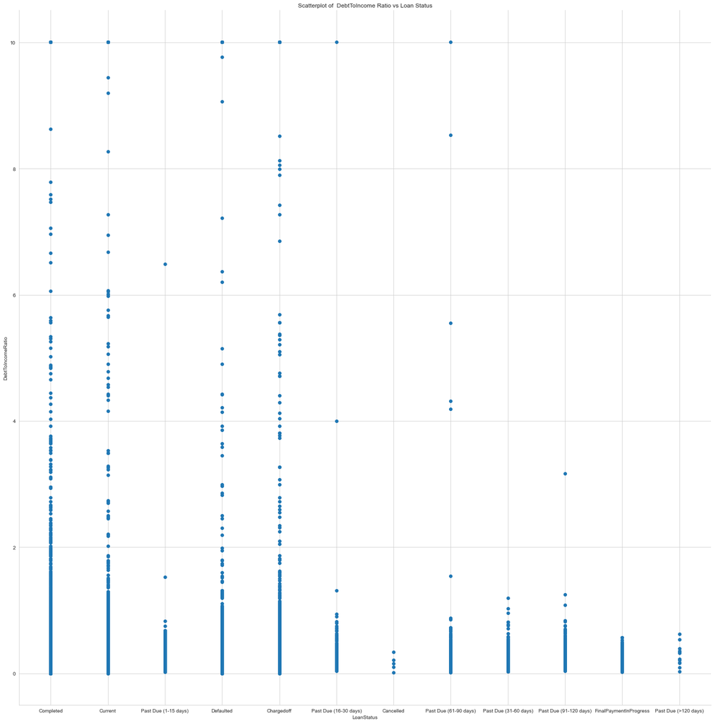

There is a strong correlation between completed loan statuses and the 1:4 debt to income ratio, which shows most clients within this ratio take out and complete the loan payment.

## Stated Monthly Income vs Loan Status

What is the relation between stated monthly income and loan status?

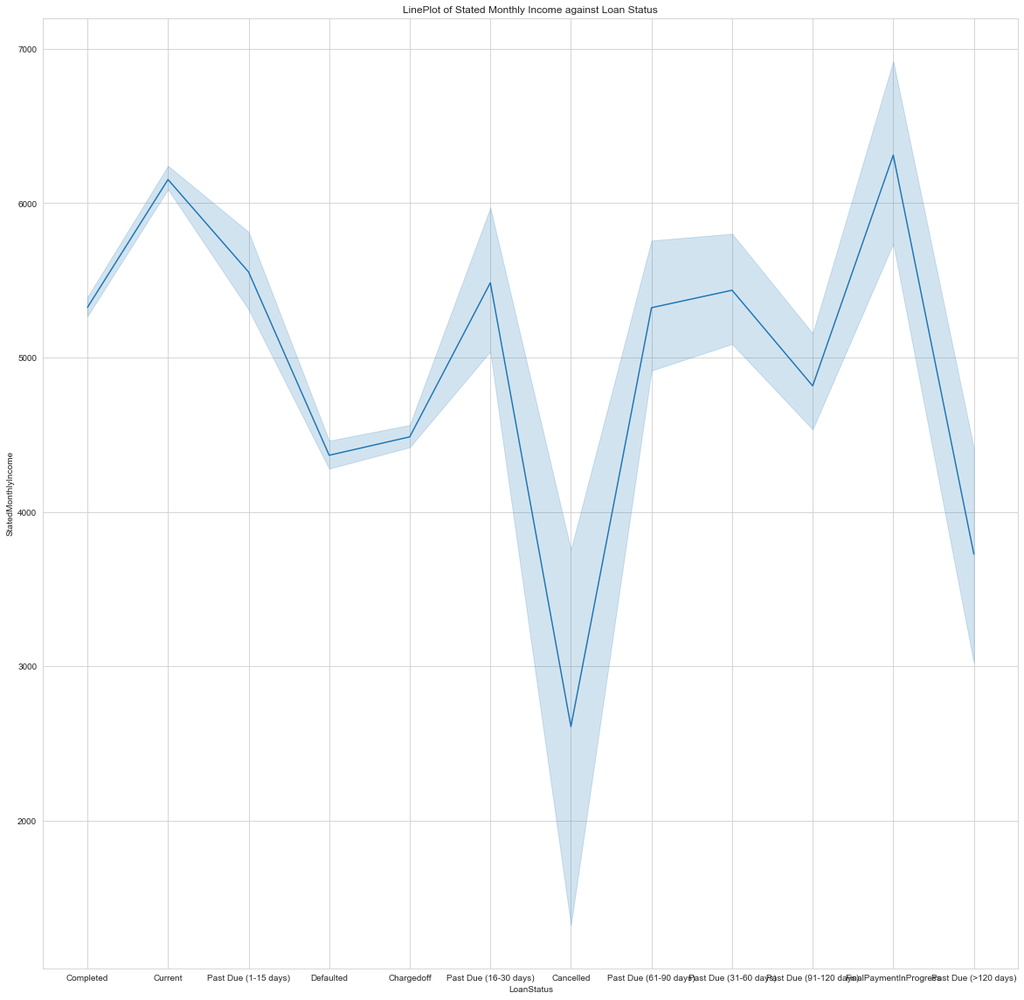

Clients of Prosper Bank with 2800 dollars stated monthly income had their loan status cancelled whereas clients with stated monthly incomes of 6200 dollars have loan status' of Payment in progress

## DebtTo Income Ratio, Income Verifiable and LoanStatus

What is the relation among Debt to Income Ratio, Income Verifiable and Loan Status?

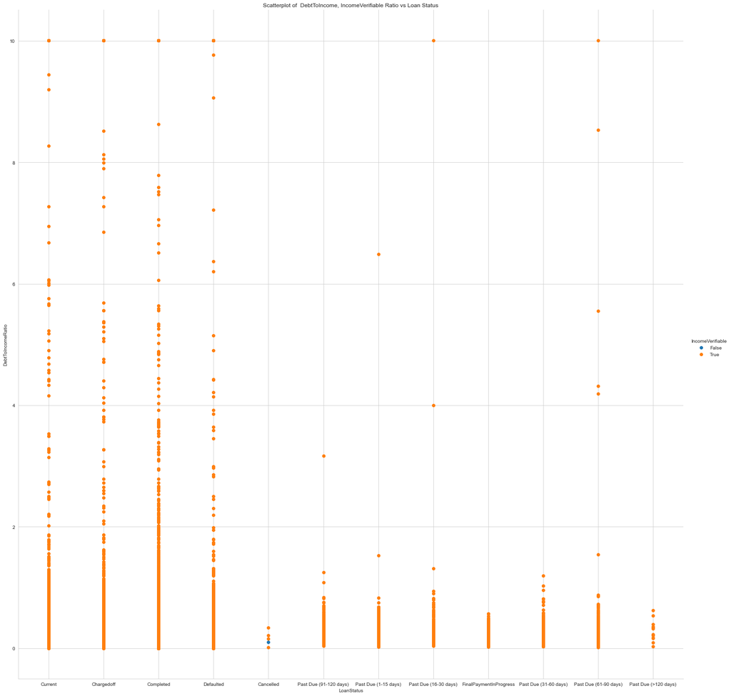

## Borrower Homeownership, LoanOriginal and Loan Status

What is the relation among Borrower Homeownership, LoanOriginal vs Loan Status?

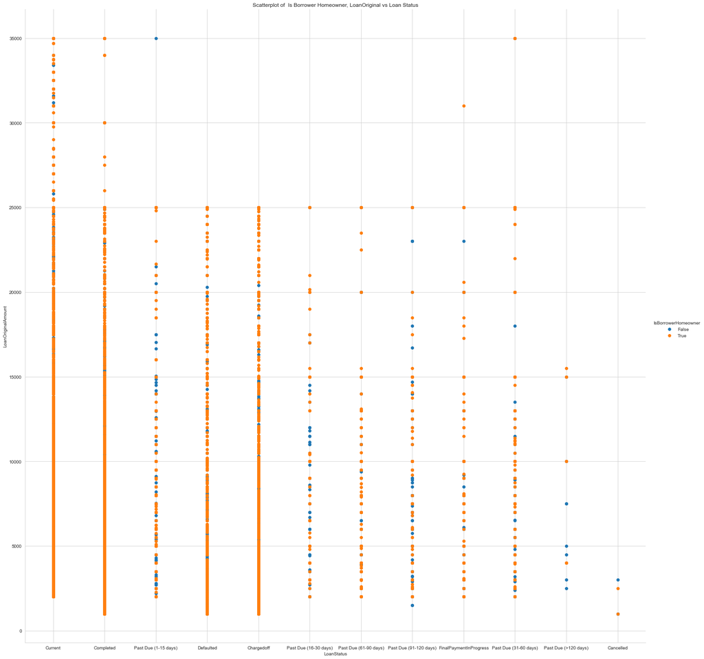